# Assignment 1: PyTorch Introduction

```python
# Instantiate the LargeNet
large_net = LargeNet()

# Training the model using the given LargeNet
train_net_new(large_net, train_loader, val_loader)
```

```
Epoch 1: Train err: 0.0026, Train loss: 0.382993 | Validation err: 0.0020, Validation loss: 0.286483
Epoch 2: Train err: 0.0017, Train loss: 0.258944 | Validation err: 0.0016, Validation loss: 0.248101
Epoch 3: Train err: 0.0014, Train loss: 0.218870 | Validation err: 0.0013, Validation loss: 0.204366
Epoch 4: Train err: 0.0012, Train loss: 0.198025 | Validation err: 0.0014, Validation loss: 0.217042
Epoch 5: Train err: 0.0012, Train loss: 0.185296 | Validation err: 0.0011, Validation loss: 0.179088
Epoch 6: Train err: 0.0011, Train loss: 0.174649 | Validation err: 0.0010, Validation loss: 0.163377
Epoch 7: Train err: 0.0010, Train loss: 0.165778 | Validation err: 0.0010, Validation loss: 0.168762
Epoch 8: Train err: 0.0009, Train loss: 0.154487 | Validation err: 0.0010, Validation loss: 0.168934
Epoch 9: Train err: 0.0009, Train loss: 0.149901 | Validation err: 0.0010, Validation loss: 0.160127
Epoch 10: Train err: 0.0009, Train loss: 0.142348 | Validation err: 0.0009, Validation loss: 0.151235
Epoch 11: Train err: 0.0008, Train loss: 0.138801 | Validation err: 0.0008, Validation loss: 0.145237
Epoch 12: Train err: 0.0008, Train loss: 0.133779 | Validation err: 0.0009, Validation loss: 0.157104
Epoch 13: Train err: 0.0008, Train loss: 0.128929 | Validation err: 0.0009, Validation loss: 0.153894
Epoch 14: Train err: 0.0007, Train loss: 0.122835 | Validation err: 0.0009, Validation loss: 0.153179
Epoch 15: Train err: 0.0007, Train loss: 0.118496 | Validation err: 0.0009, Validation loss: 0.159056
Epoch 16: Train err: 0.0007, Train loss: 0.114072 | Validation err: 0.0009, Validation loss: 0.153723
Epoch 17: Train err: 0.0007, Train loss: 0.111572 | Validation err: 0.0009, Validation loss: 0.159614
Epoch 18: Train err: 0.0006, Train loss: 0.107108 | Validation err: 0.0008, Validation loss: 0.151090
Epoch 19: Train err: 0.0006, Train loss: 0.101664 | Validation err: 0.0009, Validation loss: 0.166421
Epoch 20: Train err: 0.0006, Train loss: 0.099884 | Validation err: 0.0010, Validation loss: 0.195332
Epoch 21: Train err: 0.0006, Train loss: 0.097037 | Validation err: 0.0010, Validation loss: 0.170987
Epoch 22: Train err: 0.0005, Train loss: 0.088682 | Validation err: 0.0009, Validation loss: 0.169319
Epoch 23: Train err: 0.0005, Train loss: 0.091038 | Validation err: 0.0010, Validation loss: 0.196392
Epoch 24: Train err: 0.0005, Train loss: 0.084447 | Validation err: 0.0010, Validation loss: 0.188277
Epoch 25: Train err: 0.0005, Train loss: 0.081099 | Validation err: 0.0010, Validation loss: 0.191000
Epoch 26: Train err: 0.0005, Train loss: 0.077482 | Validation err: 0.0009, Validation loss: 0.179659
Epoch 27: Train err: 0.0004, Train loss: 0.071987 | Validation err: 0.0011, Validation loss: 0.216789
Epoch 28: Train err: 0.0004, Train loss: 0.071235 | Validation err: 0.0011, Validation loss: 0.229085
Epoch 29: Train err: 0.0004, Train loss: 0.066482 | Validation err: 0.0010, Validation loss: 0.225522
Epoch 30: Train err: 0.0004, Train loss: 0.063666 | Validation err: 0.0009, Validation loss: 0.222978
Finished Training
Total time elapsed: 731.68 seconds
```

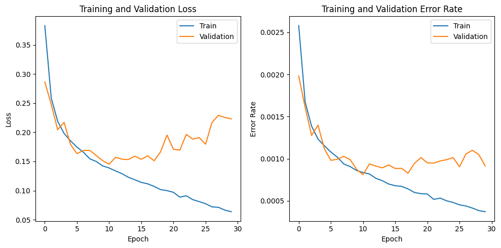

```python
import matplotlib.pyplot as plt

# Load the saved data
train_loss = np.loadtxt("train_loss_binary.csv")
val_loss = np.loadtxt("val_loss_binary.csv")
train_err = np.loadtxt("train_err_binary.csv")
val_err = np.loadtxt("val_err_binary.csv")

# Plot training and validation loss
plt.figure(figsize=(10, 5))
plt.subplot(1, 2, 1)
plt.plot(train_loss, label='Train')
plt.plot(val_loss, label='Validation')
plt.title('Training and Validation Loss')
plt.xlabel('Epoch')
plt.ylabel('Loss')
plt.legend()

# Plot training and validation error rate
plt.subplot(1, 2, 2)
plt.plot(train_err, label='Train')
plt.plot(val_err, label='Validation')
plt.title('Training and Validation Error Rate')
plt.xlabel('Epoch')
plt.ylabel('Error Rate')
plt.legend()

plt.tight_layout()
plt.show()
```

```python
'''
Preprocess images from the internet to be able to classify any
images into cars and trucks (i.e., resize, aspect ratio, etc.).
Evaluate your best model's performance on images loaded from the internet.

'''


import torch
from torchvision import transforms
from PIL import Image
import requests
from io import BytesIO

# Load the model we trained in the last step
model = LargeNet()
model.load_state_dict(torch.load('binary_classification_model.pth'))
model.eval() #evaluation mode

# Define the image preprocessing as per the given code
transform = transforms.Compose([
    transforms.Resize((32, 32)),  # Resize to match the input size of your model
    transforms.ToTensor(),
    transforms.Normalize((0.5, 0.5, 0.5), (0.5, 0.5, 0.5))  # Normalize as done during training
])

# Example URLs of car and truck images for testing
car_url = 'https://cdn.pixabay.com/photo/2012/05/29/00/43/car-49278_1280.jpg'
cat_url = 'https://as2.ftcdn.net/v2/jpg/00/97/58/97/1000_F_97589769_t45CqXyzjz0KXwoBZT9PRaWGHRk5hQqQ.jpg'

# Load images from the internet
response_car = requests.get(car_url)
response_cat = requests.get(cat_url)


img_car = Image.open(BytesIO(response_car.content))
img_cat = Image.open(BytesIO(response_cat.content))


# Preprocess the images
img_car = transform(img_car).unsqueeze(0)
img_cat = transform(img_cat).unsqueeze(0)


with torch.no_grad():
    car_prediction = model(img_car)
    cat_prediction = model(img_cat)

# Convert predictions to binary classes for images
car_class = int(car_prediction > 0)
cat_class = int(cat_prediction > 0)

# Display the results
print(f'Car Prediction: {car_class} (1: Car or truck, 0: other)')
print(f'Cat Prediction: {cat_class} (1: Car or truck, 0: other)')
```

```
Car Prediction: 1 (1: Car or truck, 0: other)
Cat Prediction: 0 (1: Car or truck, 0: other)
```

### Saving to HTML

Detailed instructions for saving to HTML can be found [here](https://stackoverflow.com/questions/53460051/convert-ipynb-notebook-to-html-in-google-colab/64487858#64487858). Provided below are a summary of the instructions:

(1) download your ipynb file by clicking on File->Download.ipynb

(2) reupload your file to the temporary Google Colab storage (you can access the temporary storage from the tab to the left)

(3) run the following:

```python
%%shell
jupyter nbconvert --to html A1_PyTorch_Introduction.ipynb
```

(4) the html file will be available for download in the temporary Google Colab storage

(5) review the html file and make sure all the results are visible before submitting your assignment to Quercus

# Assignment Grading Rubric

The grading of the assignment will be based on the following categories:

(1) **10 Pt - EXPLORATORY QUESTIONS** These are basic questions that in most cases can be answered without requiring a fully working and trained neural network model. For example, data loading, processing and visualization, summary statistics, data exploration, model and training setup, etc.

(2) **10 Pt - MODEL** Student has successfully implemented all the required neural network models and has demonstrated successful training of the model without any errors.

(3) **10 Pt - RESULT** Students are evaluated based on the results achieved in comparison to the expected results of the assignment.

(4) **10 Pt - DISCUSSION QUESTIONS** Student demonstrated understanding beyond the basic exploratory questions, can answer some of the more challenging questions, and provide arguments for their model selection decisions.

(5) **10 Pt - COMMUNICATION** Student has provided a quality submission that is easy to read without too many unnecessary output statements that distract the reading of the document. The code has been well commented and all the answers are communicated clearly and concisely.

(6) **10 Pt - BONUS** Student has completed the assignment and has taken on the challenging bonus tasks listed in PART C. The student has demonstrated a good understanding of all aspects of the assignment and has exceeded expectations for the assignment.

**TOTAL GRADE = **_** of 50 Pts**